# Predicting Salaries

## 1. Problem Definition

In this project we will be working with the UCI adult dataset. We will be attempting to predict if people in the data set belong in a certain class by salary, either making <=50k or >50k per year.

## 2. Data

http://archive.ics.uci.edu/ml/datasets/Adult

Attributes: 16

Instances: 32561

## 3. Evaluation

Binary classification - logistic regression - classification metrics

## 4. Features

age: continuous.

workclass: Private, Self-emp-not-inc, Self-emp-inc, Federal-gov, Local-gov, State-gov, Without-pay, Never-worked.

fnlwgt: continuous.

education: Bachelors, Some-college, 11th, HS-grad, Prof-school, Assoc-acdm, Assoc-voc, 9th, 7th-8th, 12th, Masters, 1st-4th, 10th, Doctorate, 5th-6th, Preschool.

education-num: continuous.

marital-status: Married-civ-spouse, Divorced, Never-married, Separated, Widowed, Married-spouse-absent, Married-AF-spouse.

occupation: Tech-support, Craft-repair, Other-service, Sales, Exec-managerial, Prof-specialty, Handlers-cleaners, Machine-op-inspct, Adm-clerical, Farming-fishing, Transport-moving, Priv-house-serv, Protective-serv, Armed-Forces.

relationship: Wife, Own-child, Husband, Not-in-family, Other-relative, Unmarried.

race: White, Asian-Pac-Islander, Amer-Indian-Eskimo, Other, Black.

sex: Female, Male.

capital-gain: continuous.

capital-loss: continuous.

hours-per-week: continuous.

country: United-States, Cambodia, England, Puerto-Rico, Canada, Germany, Outlying-US(Guam-USVI-etc), India, Japan, Greece, South, China, Cuba, Iran, Honduras, Philippines, Italy, Poland, Jamaica, Vietnam, Mexico, Portugal, Ireland, France, Dominican-Republic, Laos, Ecuador, Taiwan, Haiti, Columbia, Hungary, Guatemala, Nicaragua, Scotland, Thailand, Yugoslavia, El-Salvador, Trinadad&Tobago, Peru, Hong, Holand-Netherlands.

```r
df <- read.csv('adult_sal.csv')
head(df)
```

```
##   X age    type_employer fnlwgt education education_num            marital
## 1 1  39        State-gov  77516 Bachelors            13      Never-married
## 2 2  50 Self-emp-not-inc  83311 Bachelors            13 Married-civ-spouse
## 3 3  38          Private 215646   HS-grad             9           Divorced
## 4 4  53          Private 234721      11th             7 Married-civ-spouse
## 5 5  28          Private 338409 Bachelors            13 Married-civ-spouse
## 6 6  37          Private 284582   Masters            14 Married-civ-spouse
##          occupation  relationship  race    sex capital_gain capital_loss
## 1      Adm-clerical Not-in-family White   Male         2174            0
## 2   Exec-managerial       Husband White   Male            0            0
## 3 Handlers-cleaners Not-in-family White   Male            0            0
## 4 Handlers-cleaners       Husband Black   Male            0            0
## 5    Prof-specialty          Wife Black Female            0            0
## 6   Exec-managerial          Wife White Female            0            0
##   hr_per_week       country income
## 1          40 United-States  <=50K
## 2          13 United-States  <=50K
## 3          40 United-States  <=50K
## 4          40 United-States  <=50K
## 5          40          Cuba  <=50K
## 6          40 United-States  <=50K
```

```r
str(df)
```

```
## 'data.frame':    32561 obs. of  16 variables:
##  $ X            : int  1 2 3 4 5 6 7 8 9 10 ...
##  $ age          : int  39 50 38 53 28 37 49 52 31 42 ...
##  $ type_employer: chr  "State-gov" "Self-emp-not-inc" "Private" "Private" ...
##  $ fnlwgt       : int  77516 83311 215646 234721 338409 284582 160187 209642 45781 159449 ...
##  $ education    : chr  "Bachelors" "Bachelors" "HS-grad" "11th" ...
##  $ education_num: int  13 13 9 7 13 14 5 9 14 13 ...
##  $ marital      : chr  "Never-married" "Married-civ-spouse" "Divorced" "Married-civ-spouse" ...
##  $ occupation   : chr  "Adm-clerical" "Exec-managerial" "Handlers-cleaners" "Handlers-cleaners" ...
##  $ relationship : chr  "Not-in-family" "Husband" "Not-in-family" "Husband" ...
##  $ race         : chr  "White" "White" "White" "Black" ...
##  $ sex          : chr  "Male" "Male" "Male" "Male" ...
##  $ capital_gain : int  2174 0 0 0 0 0 0 0 14084 5178 ...
##  $ capital_loss : int  0 0 0 0 0 0 0 0 0 0 ...
##  $ hr_per_week  : int  40 13 40 40 40 40 16 45 50 40 ...
##  $ country      : chr  "United-States" "United-States" "United-States" "United-States" ...
##  $ income       : chr  "<=50K" "<=50K" "<=50K" "<=50K" ...
```

## Categorical Features

```r
library(dplyr)
```

an attribute called `X` is a copy of index, let’s drop this

```r
df <- select(df, -X)
```

There are 3 attributes that can be grouped into smaller groups

**Type employer**

```r
table(df$type_employer)
```

```
##
##                ?      Federal-gov        Local-gov     Never-worked
##             1836              960             2093                7
##          Private     Self-emp-inc Self-emp-not-inc        State-gov
##            22696             1116             2541             1298
##      Without-pay
##               14
```

```r
group_emp <- function(job){
  if(job == 'Local-gov' | job == 'State-gov'){
    return('SL-gov')
  } else if(job == 'Self-emp-inc' | job == 'Self-emp-not-inc'){
    return('Self-emp')
  } else{
    return(job)
  }
}
df$type_employer <- sapply(df$type_employer, group_emp)
```

```r
unemp <- function(job){
  if(job == 'Never-worked' | job == 'Without-pay'){
    return('Unemployed')
  } else{
    return(job)
  }
}
df$type_employer <- sapply(df$type_employer, unemp)
```

```r
table(df$type_employer)
```

```
##
##           ? Federal-gov     Private    Self-emp      SL-gov  Unemployed
##        1836         960       22696        3657        3391          21
```

**Marital status**

```r
table(df$marital)
```

```
##
##              Divorced     Married-AF-spouse    Married-civ-spouse
##                  4443                    23                 14976
## Married-spouse-absent         Never-married             Separated
##                   418                 10683                  1025
##               Widowed
##                   993
```

```r
group_marital <- function(mar){
  mar <- as.character(mar)

  if(mar == 'Separated' | mar == 'Divorced' | mar == 'Widowed'){
    return('Not-married')
  }else if(mar == 'Never-married'){
    return(mar)
  }else{
    return('Married')
  }
}

df$marital <- sapply(df$marital, group_marital)
table(df$marital)
```

```
##
##       Married Never-married   Not-married
##         15417         10683          6461
```

**Country**

```r
table(df$country)
```

```
##
##                          ?                   Cambodia
##                        583                         19
##                     Canada                      China
##                        121                         75
##                   Columbia                       Cuba
##                         59                         95
##         Dominican-Republic                    Ecuador
##                         70                         28
##                El-Salvador                    England
##                        106                         90
##                     France                    Germany
##                         29                        137
##                     Greece                  Guatemala
##                         29                         64
##                      Haiti         Holand-Netherlands
##                         44                          1
##                   Honduras                       Hong
##                         13                         20
##                    Hungary                      India
##                         13                        100
##                       Iran                    Ireland
##                         43                         24
##                      Italy                    Jamaica
##                         73                         81
##                      Japan                       Laos
##                         62                         18
##                     Mexico                  Nicaragua
##                        643                         34
## Outlying-US(Guam-USVI-etc)                       Peru
##                         14                         31
##                Philippines                     Poland
##                        198                         60
##                   Portugal                Puerto-Rico
##                         37                        114
##                   Scotland                      South
##                         12                         80
##                     Taiwan                   Thailand
##                         51                         18
##            Trinadad&Tobago              United-States
##                         19                      29170
##                    Vietnam                 Yugoslavia
##                         67                         16
```

```r
Asia <- c('China','Hong','India','Iran','Cambodia','Japan', 'Laos' ,
          'Philippines' ,'Vietnam' ,'Taiwan', 'Thailand')

North.America <- c('Canada','United-States','Puerto-Rico' )

Europe <- c('England' ,'France', 'Germany' ,'Greece','Holand-Netherlands','Hungary',
            'Ireland','Italy','Poland','Portugal','Scotland','Yugoslavia')

Latin.and.South.America <- c('Columbia','Cuba','Dominican-Republic','Ecuador',
                             'El-Salvador','Guatemala','Haiti','Honduras',
                             'Mexico','Nicaragua','Outlying-US(Guam-USVI-etc)','Peru',
                            'Jamaica','Trinadad&Tobago')
Other <- c('South')
```

```r
group_country <- function(ctry){
  if(ctry %in% Asia){
    return('Asia')
  }else if(ctry %in% North.America){
    return('North-America')
  }else if(ctry %in% Europe){
    return('Europe')
  }else if(ctry %in% Latin.and.South.America){
    return('Latin-and-South-America')
  }else{
    return('Other')
  }
}
df$country <- sapply(df$country, group_country)
table(df$country)
```

```
##
##                    Asia                  Europe Latin-and-South-America
##                     671                     521                    1301
##           North-America                   Other
##                   29405                     663
```

Lastly, turn these categorical features into factors. Factor will convert the values into numerical categories.

```r
df$type_employer <- factor(df$type_employer)
df$education <- factor(df$education)
df$marital <- factor(df$marital)
df$occupation <- factor(df$occupation)
df$relationship <- factor(df$relationship)
df$race <- factor(df$race)
df$sex <- factor(df$sex)
df$country <- factor(df$country)
df$income <- factor(df$income)

str(df)
```

```
## 'data.frame':    32561 obs. of  15 variables:
##  $ age          : int  39 50 38 53 28 37 49 52 31 42 ...
##  $ type_employer: Factor w/ 6 levels "?","Federal-gov",..: 5 4 3 3 3 3 3 4 3 3 ...
##  $ fnlwgt       : int  77516 83311 215646 234721 338409 284582 160187 209642 45781 159449 ...
##  $ education    : Factor w/ 16 levels "10th","11th",..: 10 10 12 2 10 13 7 12 13 10 ...
##  $ education_num: int  13 13 9 7 13 14 5 9 14 13 ...
##  $ marital      : Factor w/ 3 levels "Married","Never-married",..: 2 1 3 1 1 1 1 1 2 1 ...
##  $ occupation   : Factor w/ 15 levels "?","Adm-clerical",..: 2 5 7 7 11 5 9 5 11 5 ...
##  $ relationship : Factor w/ 6 levels "Husband","Not-in-family",..: 2 1 2 1 6 6 2 1 2 1 ...
##  $ race         : Factor w/ 5 levels "Amer-Indian-Eskimo",..: 5 5 5 3 3 5 3 5 5 5 ...
##  $ sex          : Factor w/ 2 levels "Female","Male": 2 2 2 2 1 1 1 2 1 2 ...
##  $ capital_gain : int  2174 0 0 0 0 0 0 0 14084 5178 ...
##  $ capital_loss : int  0 0 0 0 0 0 0 0 0 0 ...
##  $ hr_per_week  : int  40 13 40 40 40 40 16 45 50 40 ...
##  $ country      : Factor w/ 5 levels "Asia","Europe",..: 4 4 4 4 3 4 3 4 4 4 ...
##  $ income       : Factor w/ 2 levels "<=50K",">50K": 1 1 1 1 1 1 1 2 2 2 ...
```

## Dealing with Missing Data

```r
library(Amelia)
```

There are numbers of ‘?’ values in `type_employer` and `occupation`. We need to turn these values into NA.

```r
df[df == '?'] <- NA
```

```r
table(df$type_employer)
```

```
##
##           ? Federal-gov     Private    Self-emp      SL-gov  Unemployed
##           0         960       22696        3657        3391          21
```

Reassign the factor so ‘?’ will not be included.

```r
df$type_employer <- factor(df$type_employer)
df$marital <- factor(df$marital)
df$occupation <- factor(df$occupation)
df$country <- factor(df$country)

str(df)
```

```
## 'data.frame':    32561 obs. of  15 variables:
##  $ age          : int  39 50 38 53 28 37 49 52 31 42 ...
##  $ type_employer: Factor w/ 5 levels "Federal-gov",..: 4 3 2 2 2 2 2 3 2 2 ...
##  $ fnlwgt       : int  77516 83311 215646 234721 338409 284582 160187 209642 45781 159449 ...
##  $ education    : Factor w/ 16 levels "10th","11th",..: 10 10 12 2 10 13 7 12 13 10 ...
##  $ education_num: int  13 13 9 7 13 14 5 9 14 13 ...
##  $ marital      : Factor w/ 3 levels "Married","Never-married",..: 2 1 3 1 1 1 1 1 2 1 ...
##  $ occupation   : Factor w/ 14 levels "Adm-clerical",..: 1 4 6 6 10 4 8 4 10 4 ...
##  $ relationship : Factor w/ 6 levels "Husband","Not-in-family",..: 2 1 2 1 6 6 2 1 2 1 ...
##  $ race         : Factor w/ 5 levels "Amer-Indian-Eskimo",..: 5 5 5 3 3 5 3 5 5 5 ...
##  $ sex          : Factor w/ 2 levels "Female","Male": 2 2 2 2 1 1 1 2 1 2 ...
##  $ capital_gain : int  2174 0 0 0 0 0 0 0 14084 5178 ...
##  $ capital_loss : int  0 0 0 0 0 0 0 0 0 0 ...
##  $ hr_per_week  : int  40 13 40 40 40 40 16 45 50 40 ...
##  $ country      : Factor w/ 5 levels "Asia","Europe",..: 4 4 4 4 3 4 3 4 4 4 ...
##  $ income       : Factor w/ 2 levels "<=50K",">50K": 1 1 1 1 1 1 1 2 2 2 ...
```

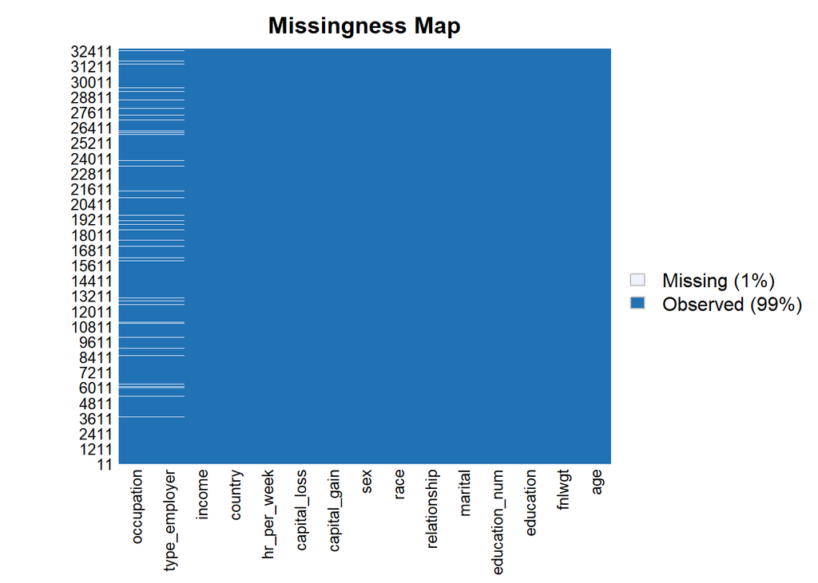

```r
missmap(df)
```

There are 1% missing values. We can drop these.

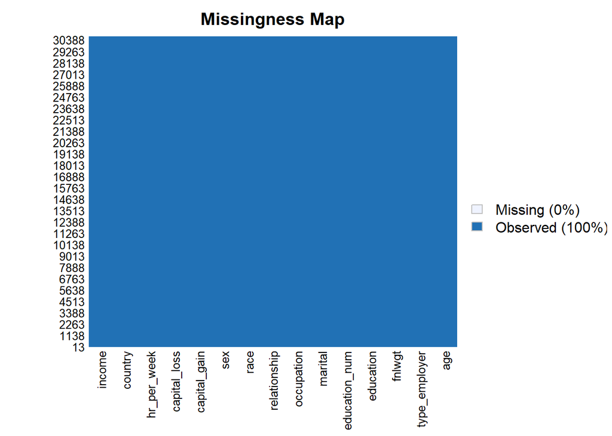

```r
df <- na.omit(df)
missmap(df)
```

## Some Visualization

```r
library(ggplot2)
```

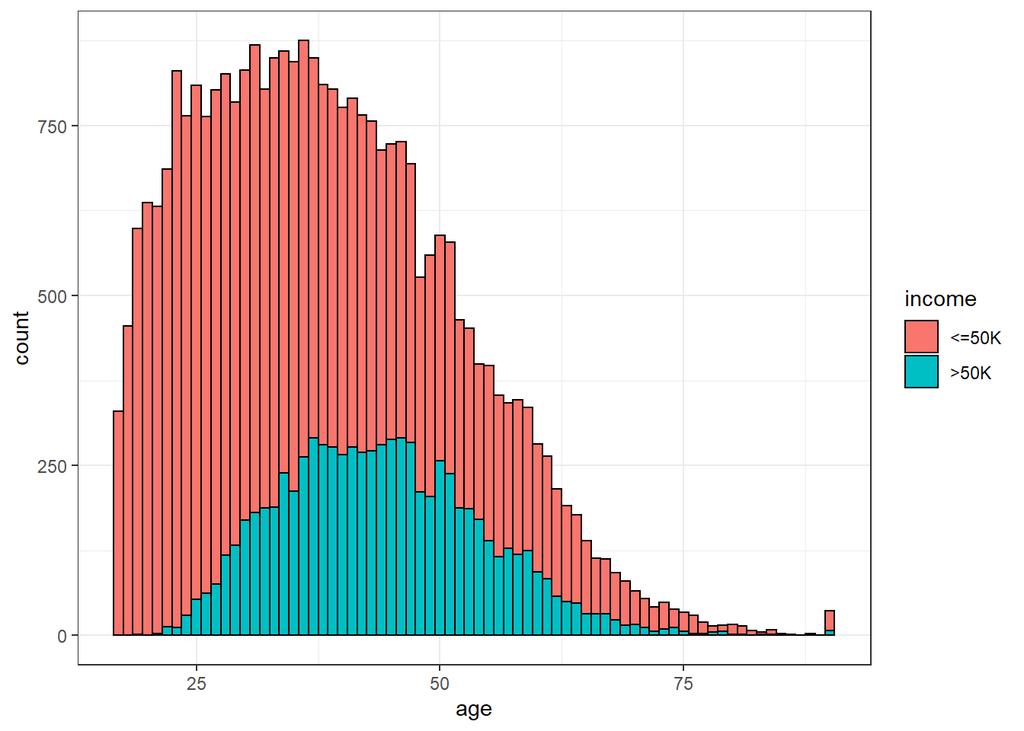

```r
ggplot(df, aes(age)) + geom_histogram(aes(fill=income), color='black', binwidth=1) + theme_bw()
```

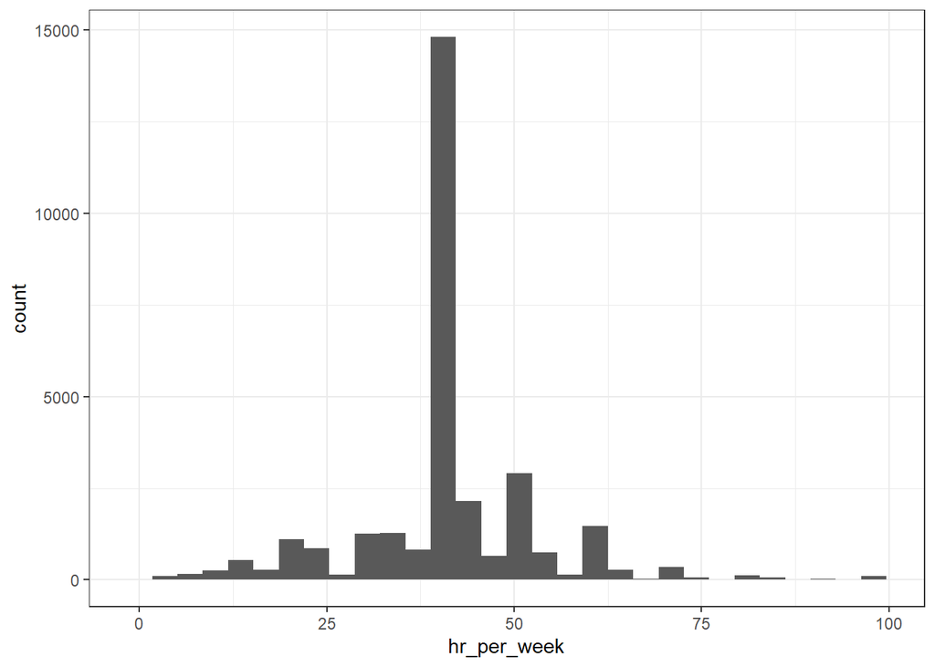

```r
ggplot(df, aes(hr_per_week)) + geom_histogram() + theme_bw()
```

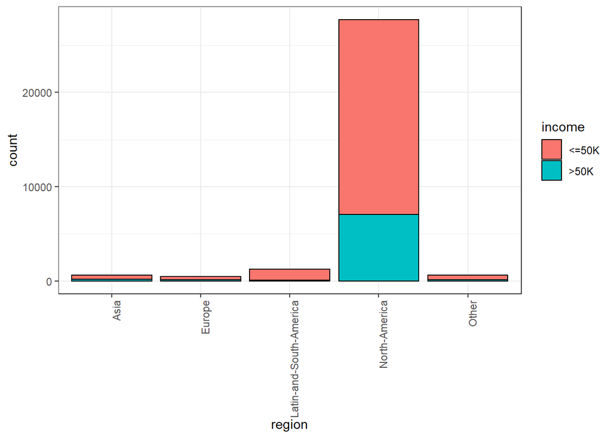

```r
names(df)[names(df) == 'country'] <- 'region'

ggplot(df, aes(region)) + geom_bar(aes(fill=income), color='black') + theme_bw() + theme(axis.text.x = element_text(angle=90, hjust=1))
```